# 個人プロジェクト

田辺大雄

2021/12/21

```r
setwd("C:/Rdata")
getwd()
```

```
## [1] "C:/Rdata"
```

```r
library(ggplot2)
library(readxl)
library(dplyr)
```

## 1. はじめに

私がこのテーマを取り上げた理由は、過去に選挙に行った際、ニュースで報道されている 通り選挙会場での私の周りには若者と思われる年代の方が少なかったため、どのようにすれば 若者の投票率が増加するのかを考える。さらに、なぜ若者の投票率が低いのか興味を持ったので このテーマを取り上げた。 まず、投票率とは「有権者総数に対する投票者の比率」を指す。選挙権を持っている国民の中でどれだけの人が投票をしたかという割合を指し、政治への関心を計る目安にもなっている。 選挙権は満１８歳以上の全ての国民が持っている権利である。2015年に公職選挙法等の一部が改正され、１８歳から投票ができるようになった。 次に、国政選挙の年代別投票率は、平成29年10月に行われた第48回衆議院議員総選挙では、10歳代が40.49％、20歳代が33.85％、30歳代が44.75％となっている。（全年代を通じた投票率は53.68％） また、令和元年7月に行われた第25回参議院議員通常選挙では、10歳代が32.28％、20歳代が30.96％、30歳代が38.78％となっている。（全年代を通じた投票率は48.80％） このように、若年層全体としては、投票率はいずれの選挙でも他の年代と比べて、低い水準にとどまっていることから、総務省では、特に若年層への選挙啓発や主権者教育に取り組むとともに、関係機関等と緊密な連携を図り、投票率の向上に努めることとしている。 では、どのようにしたら若者の投票率を上げられるのか。私は、その対策案を挙げる。 以下に、それを述べる。若者の投票率を上げるうえで、最も効果のある方法は「インターネット投票」の解禁だと思われる。 少なくとも、投票所に行くのが面倒だから行かない、という若者は一定数いるのではないだろうか。 若者のスマホ普及率は8割以上であることから、インターネット投票が解禁されれば、若者の投票率はぐんと上がる可能性が高い。 単純に若者投票率を上げることだけを考えれば、これ以上の方法は他にないだろう。 しかし、インターネット投票に関しては反対する人が多いのが現状であるがインターネットを介して投票することには、どことない「軽さ」を感じてしまう人もいる。 自分の足で投票所に出向き、自分の意思で候補者の名前を書くという行動があってこそ、選挙の重みを実感できるという人もいる。 なにより、スマホから投票できるという気軽さから、イタズラ目的に投票する者や、第三者に悪用されることも懸念される。 インターネット投票は、まさにメリットとデメリットを合わせ持つ表裏一体の方法である。

## 2. 仮説

本研究の仮説は以下の通りである。

> 「選挙での若者の投票率が増加しないのは妥当である」

## 3. 問題の背景

1. 年代別の比較
- 21 歳～24 歳（30.88％）が最も低く、年齢層が上がるとともに高くなっていて、 70 歳～74 歳（71.85％）で最も高くなり、80 歳代以上（48.69％）では低下している。
2. 前回衆議院議員選挙との比較
- 前回衆院選（H26）と年代別の投票率を比較すると、30 歳代以下の 年代では１ポイント以上下回っており、特に 20 歳で前回を８ポイント 以上下回っている。 なお、全体の投票率（公式結果）は、53.64％で、前回衆院選の 54.36％ に比べて 0.72 ポイント低くなっている。

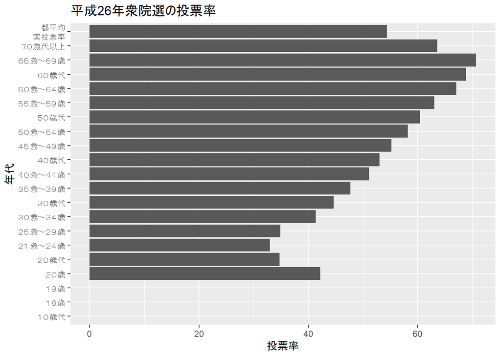

```r
setwd("C:/Rdata")
senkyoDB<-readxl::read_excel("senkyobetu_suitei_ichiran.xlsx",skip=1)

ggplot(senkyoDB)+
  geom_col(aes(x=年代別,y=衆院選H26))+
  xlab("年代")+ylab("投票率")+
  coord_flip()+
  ggtitle("平成26年衆院選の投票率")
```

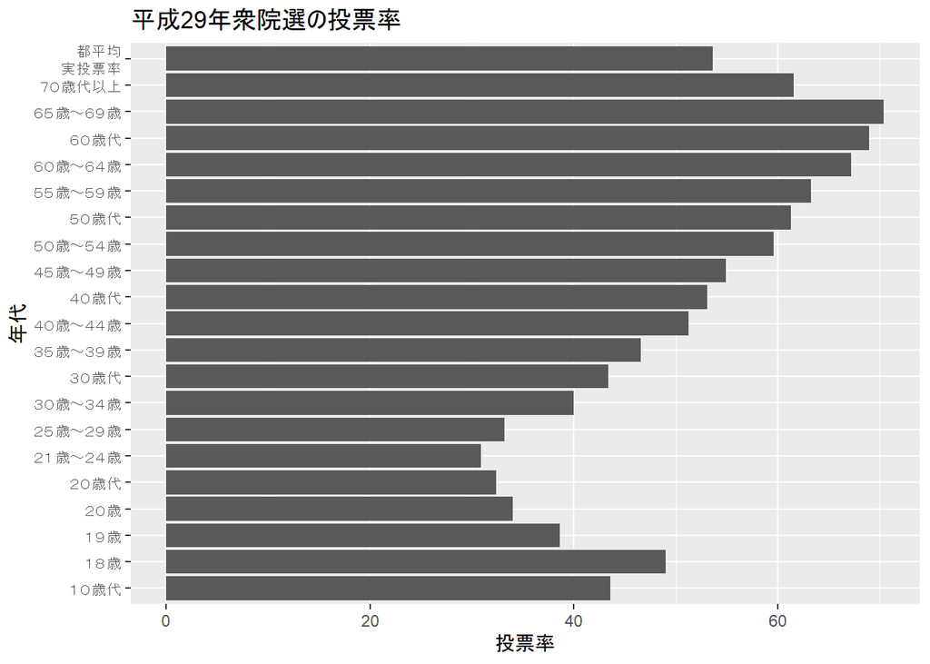

```r
setwd("C:/Rdata")
senkyoDB<-readxl::read_excel("senkyobetu_suitei_ichiran.xlsx",skip=1)

ggplot(senkyoDB)+
  geom_col(aes(x=年代別,y=衆院選H29))+
  xlab("年代")+ylab("投票率")+
  coord_flip()+
  ggtitle("平成29年衆院選の投票率")
```

## 4. 分析

### 4.1 データの紹介

第19回、第24回の参議院議員通常選挙の平均のデータを用いる。

### 4.2 分析方法

第19回参議院議員通常選挙の各都道府県、男女の投票率の平均の差

```r
setwd("C:/Rdata")
senkyoDB2<-readxl::read_excel("okayama-senkyoheikin.xlsx")

t.test(x=senkyoDB2$男, y=senkyoDB2$女)
```

```
##
##  Welch Two Sample t-test
##
## data:  senkyoDB2$男 and senkyoDB2$女
## t = -0.65698, df = 91.99, p-value = 0.5128
## alternative hypothesis: true difference in means is not equal to 0
## 95 percent confidence interval:
##  -2.285446  1.149276
## sample estimates:
## mean of x mean of y
##  58.17957  58.74766
```

第24回参議院議員通常選挙の各都道府県、18歳と19歳の投票率の平均の差

```r
setwd("C:/Rdata")
senkyoDB3<-readxl::read_excel("wakamono-senkyoheikin.xlsx")

t.test(x=senkyoDB3$`18歳`, y=senkyoDB3$`19歳`)
```

```
##
##  Welch Two Sample t-test
##
## data:  senkyoDB3$`18歳` and senkyoDB3$`19歳`
## t = 8.4478, df = 90.4, p-value = 4.696e-13
## alternative hypothesis: true difference in means is not equal to 0
## 95 percent confidence interval:
##   7.555852 12.202021
## sample estimates:
## mean of x mean of y
##  48.30447  38.42553
```

第24回参議院議員通常選挙の各都道府県、18歳-19歳と全年齢の投票率の平均の差

```r
setwd("C:/Rdata")
senkyoDB3<-readxl::read_excel("wakamono-senkyoheikin.xlsx")

t.test(x=senkyoDB3$`18-19歳`, y=senkyoDB3$全年齢)
```

```
##
##  Welch Two Sample t-test
##
## data:  senkyoDB3$`18-19歳` and senkyoDB3$全年齢
## t = -11.309, df = 79.148, p-value < 2.2e-16
## alternative hypothesis: true difference in means is not equal to 0
## 95 percent confidence interval:
##  -13.800239  -9.669548
## sample estimates:
## mean of x mean of y
##  43.23362  54.96851
```

## 5. 考察

若者が選挙に参加しない理由は、「政治に関心がない」や「会場に行くのが面倒くさい」など といった理由であるので、若者の支持を増やすには少しずつ政治にもインターネットを利用を することが重要であると考える。

## 参考文献

- 年代別投票行動調査結果 https://www.senkyo.metro.tokyo.lg.jp/election/nendaibetuchousa/
- https://blog.smartsenkyo.com/1180/
- https://www.soumu.go.jp/senkyo/senkyo_s/data/sangiin19/sangiin19_2_3.html